# Cyclistic

Rene SIlva

2022-06-30

# Google Data Analytics Capstone Project: Cyclistic bike-share analysis

## About the company

In 2016, Cyclistic launched a successful bike-share offering. Since then, the program has grown to a fleet of 5,824 bicycles that are geotracked and locked into a network of 692 stations across Chicago. The bikes can be unlocked from one station and returned to any other station in the system anytime.

Until now, Cyclistic’s marketing strategy relied on building general awareness and appealing to broad consumer segments. One approach that helped make these things possible was the flexibility of its pricing plans: single-ride passes, full-day passes, and annual memberships. Customers who purchase single-ride or full-day passes are referred to as casual riders. Customers who purchase annual memberships are Cyclistic members.

Cyclistic’s finance analysts have concluded that annual members are much more profitable than casual riders. Although the pricing flexibility helps Cyclistic attract more customers, Moreno believes that maximizing the number of annual members will be key to future growth. Rather than creating a marketing campaign that targets all-new customers, Moreno believes there is a very good chance to convert casual riders into members. She notes that casual riders are already aware of the Cyclistic program and have chosen Cyclistic for their mobility needs.

Moreno has set a clear goal: Design marketing strategies aimed at converting casual riders into annual members. In order to do that, however, the marketing analyst team needs to better understand how annual members and casual riders differ why casual riders would buy a membership, and how digital media could affect their marketing tactics. Moreno and her team are interested in analyzing the Cyclistic historical bike trip data to identify trends.

## Scenario

You are a junior data analyst working in the marketing analyst team at Cyclistic, a bike-share company in Chicago. The director of marketing believes the company’s future success depends on maximizing the number of annual memberships. Therefore, your team wants to understand how casual riders and annual members use Cyclistic bikes differently. From these insights, your team will design a new marketing strategy to convert casual riders into annual members. But first, Cyclistic executives must approve your recommendations, so they must be backed up with compelling data insights and professional data visualizations.

Moreno has assigned you the first question to answer: How do annual members and casual riders use Cyclistic bikes differently?

## Business Task

Analyze rider’s usage patterns for marketing membership conversion programs.

**Tools:** R programming

**Dataset:** [Cyclistic’s historical trip data from May 2021 to May 2022](https://divvy-tripdata.s3.amazonaws.com/index.html)

## Step 1:Prework

### Install Libraries

```r
#install.packages('rmarkdown')
#install.packages('tidyverse')
#install.packages('lubridate')
#install.packages('skimr')
#install.packages('janitor')
#install.packages('ggplot2')
#install.packages('dplyr')
```

### Load Libraries

```r
library(rmarkdown)
library(tidyverse)
library(lubridate)
library(skimr)
library(janitor)
```

```r
library(ggplot2)
library(dplyr)
```

## Step 2: Load Data

```r
Trips_May21 <- read_csv('202105-divvy-tripdata.csv')
Trips_June21 <- read_csv('202106-divvy-tripdata.csv')
Trips_July21 <- read_csv('202107-divvy-tripdata.csv')
Trips_Aug21 <- read_csv('202108-divvy-tripdata.csv')
Trips_Sept21 <- read_csv('202109-divvy-tripdata.csv')
Trips_Oct21 <- read_csv('202110-divvy-tripdata.csv')
Trips_Nov21 <- read_csv('202111-divvy-tripdata.csv')
Trips_Dec21 <- read_csv('202112-divvy-tripdata.csv')
Trips_Jan22 <- read_csv('202201-divvy-tripdata.csv')
Trips_Feb22 <- read_csv('202202-divvy-tripdata.csv')
Trips_Mar22 <- read_csv('202203-divvy-tripdata.csv')
Trips_Apr22 <- read_csv('202204-divvy-tripdata.csv')
Trips_May22 <- read_csv('202205-divvy-tripdata.csv')
```

### View Columns of Data

```r
colnames(Trips_May21)
```

```
##  [1] "ride_id"            "rideable_type"      "started_at"
##  [4] "ended_at"           "start_station_name" "start_station_id"
##  [7] "end_station_name"   "end_station_id"     "start_lat"
## [10] "start_lng"          "end_lat"            "end_lng"
## [13] "member_casual"
```

```r
colnames(Trips_June21)
```

```
##  [1] "ride_id"            "rideable_type"      "started_at"
##  [4] "ended_at"           "start_station_name" "start_station_id"
##  [7] "end_station_name"   "end_station_id"     "start_lat"
## [10] "start_lng"          "end_lat"            "end_lng"
## [13] "member_casual"
```

```r
colnames(Trips_July21)
```

```
##  [1] "ride_id"            "rideable_type"      "started_at"
##  [4] "ended_at"           "start_station_name" "start_station_id"
##  [7] "end_station_name"   "end_station_id"     "start_lat"
## [10] "start_lng"          "end_lat"            "end_lng"
## [13] "member_casual"
```

```r
colnames(Trips_Aug21)
```

```
##  [1] "ride_id"            "rideable_type"      "started_at"
##  [4] "ended_at"           "start_station_name" "start_station_id"
##  [7] "end_station_name"   "end_station_id"     "start_lat"
## [10] "start_lng"          "end_lat"            "end_lng"
## [13] "member_casual"
```

```r
colnames(Trips_Sept21)
```

```
##  [1] "ride_id"            "rideable_type"      "started_at"
##  [4] "ended_at"           "start_station_name" "start_station_id"
##  [7] "end_station_name"   "end_station_id"     "start_lat"
## [10] "start_lng"          "end_lat"            "end_lng"
## [13] "member_casual"
```

```r
colnames(Trips_Oct21)
```

```
##  [1] "ride_id"            "rideable_type"      "started_at"
##  [4] "ended_at"           "start_station_name" "start_station_id"
##  [7] "end_station_name"   "end_station_id"     "start_lat"
## [10] "start_lng"          "end_lat"            "end_lng"
## [13] "member_casual"
```

```r
colnames(Trips_Nov21)
```

```
##  [1] "ride_id"            "rideable_type"      "started_at"
##  [4] "ended_at"           "start_station_name" "start_station_id"
##  [7] "end_station_name"   "end_station_id"     "start_lat"
## [10] "start_lng"          "end_lat"            "end_lng"
## [13] "member_casual"
```

```r
colnames(Trips_Dec21)
```

```
##  [1] "ride_id"            "rideable_type"      "started_at"
##  [4] "ended_at"           "start_station_name" "start_station_id"
##  [7] "end_station_name"   "end_station_id"     "start_lat"
## [10] "start_lng"          "end_lat"            "end_lng"
## [13] "member_casual"
```

```r
colnames(Trips_Jan22)
```

```
##  [1] "ride_id"            "rideable_type"      "started_at"
##  [4] "ended_at"           "start_station_name" "start_station_id"
##  [7] "end_station_name"   "end_station_id"     "start_lat"
## [10] "start_lng"          "end_lat"            "end_lng"
## [13] "member_casual"
```

```r
colnames(Trips_Feb22)
```

```
##  [1] "ride_id"            "rideable_type"      "started_at"
##  [4] "ended_at"           "start_station_name" "start_station_id"
##  [7] "end_station_name"   "end_station_id"     "start_lat"
## [10] "start_lng"          "end_lat"            "end_lng"
## [13] "member_casual"
```

```r
colnames(Trips_Mar22)
```

```
##  [1] "ride_id"            "rideable_type"      "started_at"
##  [4] "ended_at"           "start_station_name" "start_station_id"
##  [7] "end_station_name"   "end_station_id"     "start_lat"
## [10] "start_lng"          "end_lat"            "end_lng"
## [13] "member_casual"
```

```r
colnames(Trips_Apr22)
```

```
##  [1] "ride_id"            "rideable_type"      "started_at"
##  [4] "ended_at"           "start_station_name" "start_station_id"
##  [7] "end_station_name"   "end_station_id"     "start_lat"
## [10] "start_lng"          "end_lat"            "end_lng"
## [13] "member_casual"
```

```r
colnames(Trips_May22)
```

```
##  [1] "ride_id"            "rideable_type"      "started_at"
##  [4] "ended_at"           "start_station_name" "start_station_id"
##  [7] "end_station_name"   "end_station_id"     "start_lat"
## [10] "start_lng"          "end_lat"            "end_lng"
## [13] "member_casual"
```

### Compare Column Datatypes

```r
compare_df_cols(Trips_May21, Trips_June21, Trips_July21, Trips_Aug21, Trips_Sept21, Trips_Oct21, Trips_Nov21, Trips_Dec21, Trips_Jan22, Trips_Feb22, Trips_Mar22,Trips_Apr22, Trips_May22, return = "mismatch")
```

| column_name | Trips_May21 | Trips_June21 | Trips_July21 | Trips_Aug21 | Trips_Sept21 | Trips_Oct21 | Trips_Nov21 | Trips_Dec21 | Trips_Jan22 | Trips_Feb22 | Trips_Mar22 | Trips_Apr22 | Trips_May22 |
| --- | --- | --- | --- | --- | --- | --- | --- | --- | --- | --- | --- | --- | --- |

# Step 3: Combine all data into one dataset

```r
all_trips <- bind_rows(Trips_May21, Trips_June21, Trips_July21, Trips_Aug21, Trips_Sept21, Trips_Oct21, Trips_Nov21, Trips_Dec21, Trips_Jan22, Trips_Feb22, Trips_Mar22,Trips_Apr22, Trips_May22)
```

## Remove unncessary columns

```r
all_trips <- all_trips %>% select(-c(start_lat, start_lng, end_lat, end_lng))
```

## Rename columns

```r
all_trips <- all_trips %>% rename(trip_id = ride_id, ride_type = rideable_type, start_time = started_at, end_time = ended_at, from_station_name = start_station_name, from_station_id = start_station_id, to_station_name = end_station_name, to_station_id = end_station_id, usertype = member_casual)
```

## Check column names, dimensions, and first 6 rows of data frame

```r
colnames(all_trips)
```

```
## [1] "trip_id"           "ride_type"         "start_time"
## [4] "end_time"          "from_station_name" "from_station_id"
## [7] "to_station_name"   "to_station_id"     "usertype"
```

```r
dim(all_trips)
```

```
## [1] 6392409       9
```

```r
head(all_trips)
```

| trip_id | ride_type | start_time | end_time | from_station_name | from_station_id | to_station_name | to_station_id | usertype |
| --- | --- | --- | --- | --- | --- | --- | --- | --- |
| C809ED75D6160B2A | electric_bike | 2021-05-30 11:58:15 | 2021-05-30 12:10:39 | NA | NA | NA | NA | casual |
| DD59FDCE0ACACAF3 | electric_bike | 2021-05-30 11:29:14 | 2021-05-30 12:14:09 | NA | NA | NA | NA | casual |
| 0AB83CB88C43EFC2 | electric_bike | 2021-05-30 14:24:01 | 2021-05-30 14:25:13 | NA | NA | NA | NA | casual |
| 7881AC6D39110C60 | electric_bike | 2021-05-30 14:25:51 | 2021-05-30 14:41:04 | NA | NA | NA | NA | casual |
| 853FA701B4582BAF | electric_bike | 2021-05-30 18:15:39 | 2021-05-30 18:22:32 | NA | NA | NA | NA | casual |
| F5E63DFD96B2A737 | electric_bike | 2021-05-30 11:33:41 | 2021-05-30 11:57:17 | NA | NA | NA | NA | casual |

## Check member_casual and rideable_type column to if there are any discrepancies on the rider and bike type

```r
unique(all_trips$usertype)
```

```
## [1] "casual" "member"
```

```r
unique(all_trips$ride_type)
```

```
## [1] "electric_bike" "classic_bike"  "docked_bike"
```

## Remove observations with NA

```r
all_trips <- drop_na(all_trips)
```

## Check for test stations

```r
unique(all_trips$from_station_name[grep("TEST", all_trips$from_station_name)])
```

```
## character(0)
```

```r
unique(all_trips$from_station_name[grep("test", all_trips$from_station_name)])
```

```
## character(0)
```

## Add columns that list the date, month, day, and year of each ride and a “ride_length” column in seconds

```r
all_trips$date <- as.Date(all_trips$start_time)
all_trips$month <- format(as.Date(all_trips$date), "%B")
all_trips$day <- format(as.Date(all_trips$date), "%d")
all_trips$year <- format(as.Date(all_trips$date), "%Y")
all_trips$day_of_week <- weekdays(all_trips$date)
all_trips$ride_length <- difftime(all_trips$end_time,all_trips$start_time)
```

## Convert ride_length column to numeric and to minutes

```r
all_trips$ride_length<- as.numeric(as.character(all_trips$ride_length))

is.numeric(all_trips$ride_length)
```

```
## [1] TRUE
```

```r
all_trips$ride_length <- all_trips$ride_length/60

all_trips$ride_length <- round(all_trips$ride_length, 2)
```

## Inspect Ride Length column

```r
skim(all_trips$ride_length)
```

Data summary

| Name | all_trips$ride_length |
| --- | --- |
| Number of rows | 5118293 |
| Number of columns | 1 |
| _______________________ |  |
| Column type frequency: |  |
| numeric | 1 |
| ________________________ |  |
| Group variables | None |

**Variable type: numeric**

| skim_variable | n_missing | complete_rate | mean | sd | p0 | p25 | p50 | p75 | p100 | hist |
| --- | --- | --- | --- | --- | --- | --- | --- | --- | --- | --- |
| data | 0 | 1 | 20.77 | 164.88 | -55.9 | 6.68 | 11.78 | 21.38 | 55944.15 | ▇▁▁▁▁ |

One can see that there is some ride_lengths that were negative. Thus, those ride_lengths will skew our data. Needless to say one must get rid of them.

## Remove negative ride lengths

```r
all_trips <- filter(all_trips, ride_length > 0)
```

# Step 4: Descriptive Analysis

## Descriptive analysis of ride length column

```r
summary(all_trips$ride_length)
```

```
##     Min.  1st Qu.   Median     Mean  3rd Qu.     Max.
##     0.02     6.68    11.78    20.77    21.38 55944.15
```

## Stats on ride_length for each usertype

```r
all_trips %>%
  group_by(usertype) %>%
  summarise(avg_ride_length = mean(ride_length), median_ride_length = median(ride_length), max_ride_length = max(ride_length), min_ride_length = min(ride_length))
```

| usertype | avg_ride_length | median_ride_length | max_ride_length | min_ride_length |
| --- | --- | --- | --- | --- |
| casual | 31.02659 | 16.28 | 55944.15 | 0.02 |
| member | 12.81192 | 9.37 | 1495.63 | 0.02 |

One can see that the casual ride’s max is fairly large compared to the max for member riders. This provides one with a snese that the max for the casual rider can be an outlier. Lets dive into this more by looking at a descriptive analysis of the usertypes.

## Descriptive analysis for each usertype (casual riders)

```r
all_trips %>%
  filter(usertype == "casual") %>%
  summary(all_trips$ride_length)
```

```
##    trip_id           ride_type           start_time
##  Length:2235959     Length:2235959     Min.   :2021-05-01 00:00:31.0
##  Class :character   Class :character   1st Qu.:2021-07-03 22:17:06.5
##  Mode  :character   Mode  :character   Median :2021-08-21 01:55:49.0
##                                        Mean   :2021-09-22 21:56:15.2
##                                        3rd Qu.:2021-10-22 15:25:53.5
##                                        Max.   :2022-05-31 23:59:56.0
##     end_time                      from_station_name  from_station_id
##  Min.   :2021-05-01 00:08:11.00   Length:2235959     Length:2235959
##  1st Qu.:2021-07-03 22:51:59.50   Class :character   Class :character
##  Median :2021-08-21 02:21:45.00   Mode  :character   Mode  :character
##  Mean   :2021-09-22 22:27:16.89
##  3rd Qu.:2021-10-22 15:49:58.00
##  Max.   :2022-06-01 13:45:01.00
##  to_station_name    to_station_id        usertype              date
##  Length:2235959     Length:2235959     Length:2235959     Min.   :2021-05-01
##  Class :character   Class :character   Class :character   1st Qu.:2021-07-03
##  Mode  :character   Mode  :character   Mode  :character   Median :2021-08-21
##                                                           Mean   :2021-09-22
##                                                           3rd Qu.:2021-10-22
##                                                           Max.   :2022-05-31
##     month               day                year           day_of_week
##  Length:2235959     Length:2235959     Length:2235959     Length:2235959
##  Class :character   Class :character   Class :character   Class :character
##  Mode  :character   Mode  :character   Mode  :character   Mode  :character
##
##
##
##   ride_length
##  Min.   :    0.02
##  1st Qu.:    9.28
##  Median :   16.28
##  Mean   :   31.03
##  3rd Qu.:   29.97
##  Max.   :55944.15
```

## Descriptive analysis for each usertype (member riders)

```r
all_trips %>%
  filter(usertype == "member") %>%
  summary(all_trips$ride_length)
```

```
##    trip_id           ride_type           start_time
##  Length:2882092     Length:2882092     Min.   :2021-05-01 00:00:11.00
##  Class :character   Class :character   1st Qu.:2021-07-19 13:53:05.50
##  Mode  :character   Mode  :character   Median :2021-09-23 17:54:22.50
##                                        Mean   :2021-10-20 04:59:31.29
##                                        3rd Qu.:2022-01-16 11:25:32.25
##                                        Max.   :2022-05-31 23:59:23.00
##     end_time                      from_station_name  from_station_id
##  Min.   :2021-05-01 00:03:26.00   Length:2882092     Length:2882092
##  1st Qu.:2021-07-19 14:05:39.75   Class :character   Class :character
##  Median :2021-09-23 18:07:31.50   Mode  :character   Mode  :character
##  Mean   :2021-10-20 05:12:20.01
##  3rd Qu.:2022-01-16 11:36:30.25
##  Max.   :2022-06-01 16:45:51.00
##  to_station_name    to_station_id        usertype              date
##  Length:2882092     Length:2882092     Length:2882092     Min.   :2021-05-01
##  Class :character   Class :character   Class :character   1st Qu.:2021-07-19
##  Mode  :character   Mode  :character   Mode  :character   Median :2021-09-23
##                                                           Mean   :2021-10-19
##                                                           3rd Qu.:2022-01-16
##                                                           Max.   :2022-05-31
##     month               day                year           day_of_week
##  Length:2882092     Length:2882092     Length:2882092     Length:2882092
##  Class :character   Class :character   Class :character   Class :character
##  Mode  :character   Mode  :character   Mode  :character   Mode  :character
##
##
##
##   ride_length
##  Min.   :   0.02
##  1st Qu.:   5.50
##  Median :   9.37
##  Mean   :  12.81
##  3rd Qu.:  15.95
##  Max.   :1495.63
```

## Find the max rows of each usertype

```r
all_trips %>% group_by(usertype) %>% slice_max(ride_length)
```

| trip_id | ride_type | start_time | end_time | from_station_name | from_station_id | to_station_name | to_station_id | usertype | date | month | day | year | day_of_week | ride_length |
| --- | --- | --- | --- | --- | --- | --- | --- | --- | --- | --- | --- | --- | --- | --- |
| F043F0F6A1AA4F85 | docked_bike | 2021-06-05 02:27:26 | 2021-07-13 22:51:35 | Michigan Ave & Lake St | TA1305000011 | Malcolm X College Vaccination Site | 631 | casual | 2021-06-05 | June | 05 | 2021 | Saturday | 55944.15 |
| 1E1F59A64365E939 | classic_bike | 2021-06-12 20:13:13 | 2021-06-13 21:08:51 | Paulina St & 18th St | TA1307000159 | Wabash Ave & Grand Ave | TA1307000117 | member | 2021-06-12 | June | 12 | 2021 | Saturday | 1495.63 |

The casual rider rode on a docked bike from Michigan Ave & Lake St to Malcolm X College Vaccination Site for over a month. Using the resource of Google Maps the average cyclist would take 25 minutes to complete this journey. The member rider rode a casual bike from Paulina St & 18th St station to Wabash Ave & Grand Ave station for over a day. For the purpose of this study the max times will be left untouch.

## Order days of the week and month

```r
all_trips$day_of_week <- ordered(all_trips$day_of_week, levels=c("Sunday", "Monday", "Tuesday", "Wednesday", "Thursday", "Friday", "Saturday"))

all_trips$month <- ordered(all_trips$month, levels=c("January", "February", "March", "April", "May", "June", "July", "August", "September", "October", "November", "December"))
```

## Check the average ride length for each day by each usertype

```r
aggregate(all_trips$ride_length ~ all_trips$usertype + all_trips$day_of_week, FUN = mean)
```

| all_trips$usertype | all_trips$day_of_week | all_trips$ride_length |
| --- | --- | --- |
| casual | Sunday | 35.93292 |
| member | Sunday | 14.68656 |
| casual | Monday | 31.07106 |
| member | Monday | 12.41589 |
| casual | Tuesday | 26.52080 |
| member | Tuesday | 11.91304 |
| casual | Wednesday | 27.05399 |
| member | Wednesday | 12.13557 |
| casual | Thursday | 27.61064 |
| member | Thursday | 12.15625 |

[output cut: 4 more lines]

## All rides by day of the week and type of rider

```r
all_trips_by_day <- all_trips %>%
  group_by(usertype, day_of_week) %>%
  summarise(number_of_rides = n(), average_duration = mean(ride_length)) %>%
  arrange(usertype, day_of_week)
head(all_trips_by_day,14)
```

| usertype | day_of_week | number_of_rides | average_duration |
| --- | --- | --- | --- |
| casual | Sunday | 438741 | 35.93292 |
| casual | Monday | 263502 | 31.07106 |
| casual | Tuesday | 233139 | 26.52080 |
| casual | Wednesday | 236358 | 27.05399 |
| casual | Thursday | 255145 | 27.61064 |
| casual | Friday | 304808 | 29.05188 |
| casual | Saturday | 504266 | 33.60176 |
| member | Sunday | 350043 | 14.68656 |
| member | Monday | 410998 | 12.41589 |
| member | Tuesday | 453572 | 11.91304 |

[output cut: 4 more lines]

## Analyze ridership data by type and weekday

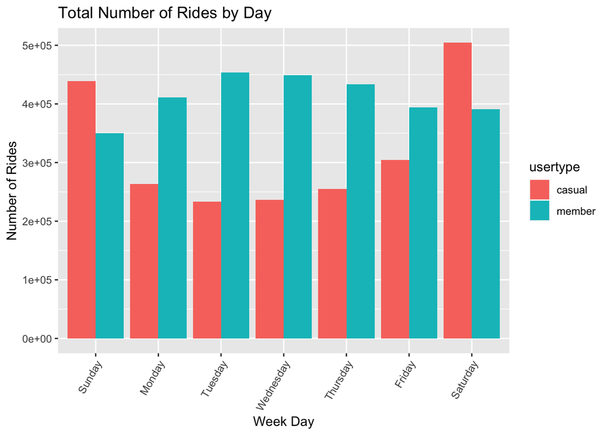

```r
all_trips %>%
  group_by(usertype, day_of_week) %>%
  summarise(number_of_rides = n(), average_duration = mean(ride_length)) %>%
  arrange(usertype, day_of_week)%>%
  ggplot(aes(x = day_of_week, y = number_of_rides, fill = usertype)) +
  geom_col(position = "dodge") + labs(title="Total Number of Rides by Day", x = "Week Day", y = "Number of Rides") + theme(axis.text.x = element_text(angle = 60, hjust = 1))
```

One can see on the y axis of the graph that it shows numbers in scientific notation. For a cleaner looking graph one should turn off scientific notation.

## Turn off scientific notation

```r
options(scipen=999)
```

## Run the visualization from above again

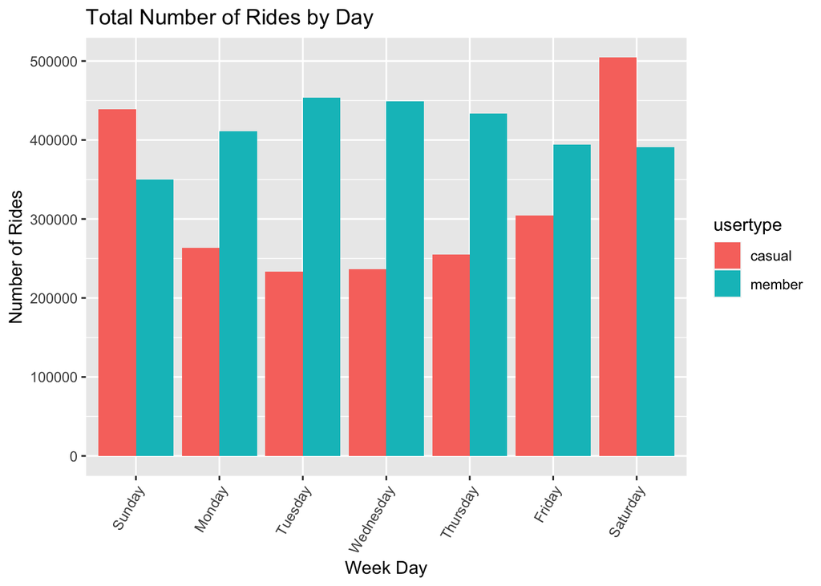

```r
all_trips %>%
  group_by(usertype, day_of_week) %>%
  summarise(number_of_rides = n(), average_duration = mean(ride_length)) %>%
  arrange(usertype, day_of_week)%>%
  ggplot(aes(x = day_of_week, y = number_of_rides, fill = usertype)) +
  geom_col(position = "dodge") + labs(title="Total Number of Rides by Day", x = "Week Day", y = "Number of Rides") + theme(axis.text.x = element_text(angle = 60, hjust = 1))
```

The y axis is now no longer in scientific notation. One can see that casual users ride more during Saturdays and Sundays than members. The members, however, ride more during the week.

## Find total casual rides on Saturday and Sunday

```r
total_rides_casual_sat_sun <- NROW(filter(all_trips, usertype == "casual" & (day_of_week == "Saturday" | day_of_week == "Sunday")))

total_rides_casual_sat_sun
```

```
## [1] 943007
```

## Find total casual rides during the week, Monday through Friday

```r
total_rides_casual_mon_fri <- NROW(filter(all_trips, usertype == "casual" & !(day_of_week == "Saturday" | day_of_week == "Sunday")))

total_rides_casual_mon_fri
```

```
## [1] 1292952
```

There are 1292952 total casual rides during the week, Monday through Friday

## Percentage of casual riders on Saturday, Sunday compared to Monday through Friday

```r
labs <- c("Mon-Friday", "Sat-Sun")
slices_casual_week <- c(total_rides_casual_mon_fri, total_rides_casual_sat_sun)
piepercent <- round(100 * slices_casual_week / sum(slices_casual_week), 1)
lbls <- paste(labs, piepercent)
lbls_casual_week <- paste(lbls, "%", sep="")

lbls_casual_week
```

```
## [1] "Mon-Friday 57.8%" "Sat-Sun 42.2%"
```

Accounting all the rides for casual riders there is approximately 58% of casual rides being done during the week and 42% of casual rides being done the weekend.

## Analyze ridership

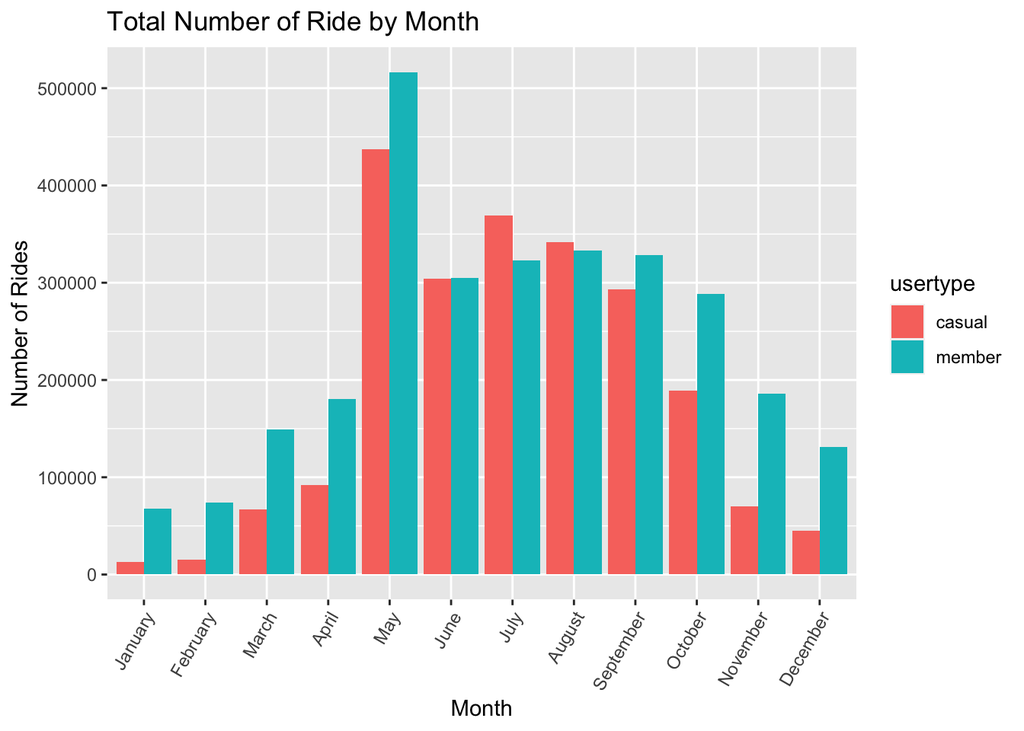

```r
all_trips %>%
  group_by(usertype, month) %>%
  summarise(number_of_rides = n(), average_duration = mean(ride_length)) %>%
  arrange(usertype, month)  %>%
  ggplot(aes(x = month, y = number_of_rides, fill = usertype)) +
  geom_col(position = "dodge") + labs(title="Total Number of Ride by Month", x = "Month", y = "Number of Rides") + theme(axis.text.x = element_text(angle = 60, hjust = 1))
```

## Compare summer month rides for casual riders to the rest of the year

```r
total_rides_casual_june_sept <- NROW(filter(all_trips, usertype == "casual" & (month == "June" | month == "July" | month == "August" | month == "September")))

total_rides_casual_june_sept
```

```
## [1] 1307968
```

```r
total_rides_casual_except_june_sept <- NROW(filter(all_trips, usertype == "casual" & !(month == "June" | month == "July" | month == "August" | month == "September")))

total_rides_casual_except_june_sept
```

```
## [1] 927991
```

## Percentage of casual riders in the summer compared to rest of the year

```r
labs <- c("June To Sept", "Rest of the Year")
slices_casual_month <- c(total_rides_casual_june_sept, total_rides_casual_except_june_sept)
piepercent <- round(100 * slices_casual_month / sum(slices_casual_month), 1)
lbls <- paste(labs, piepercent)
lbls_casual_month <- paste(lbls, "%", sep="")


lbls_casual_month
```

```
## [1] "June To Sept 58.5%"     "Rest of the Year 41.5%"
```

More than half of casual rides are occuring in the summer time.

## Compare summer month rides for member riders to the rest of the year

```r
total_rides_member_june_sept <- NROW(filter(all_trips, usertype == "member" & (month == "June" | month == "July" | month == "August" | month == "September")))

total_rides_member_june_sept
```

```
## [1] 1288568
```

```r
total_rides_member_except_june_sept <- NROW(filter(all_trips, usertype == "member" & !(month == "June" | month == "July" | month == "August" | month == "September")))

total_rides_member_except_june_sept
```

```
## [1] 1593524
```

## Percentage of member riders by month - June to September compared to rest of the year

```r
labs <- c("June To Sept", "Rest of the Year")
slices_member_month <- c(total_rides_member_june_sept, total_rides_member_except_june_sept)
piepercent <- round(100 * slices_member_month / sum(slices_member_month), 1)
lbls <- paste(labs, piepercent)
lbls_member_month <- paste(lbls, "%", sep="")


lbls_member_month
```

```
## [1] "June To Sept 44.7%"     "Rest of the Year 55.3%"
```

More member rides are occurring outside of summer.

## Create a dataset for casual riders and member riders

```r
all_trips_casual <-  filter(all_trips, usertype == "casual")

all_trips_member <-  filter(all_trips, usertype == "member")
```

## Analyze casual riders bike type usage by day of the week

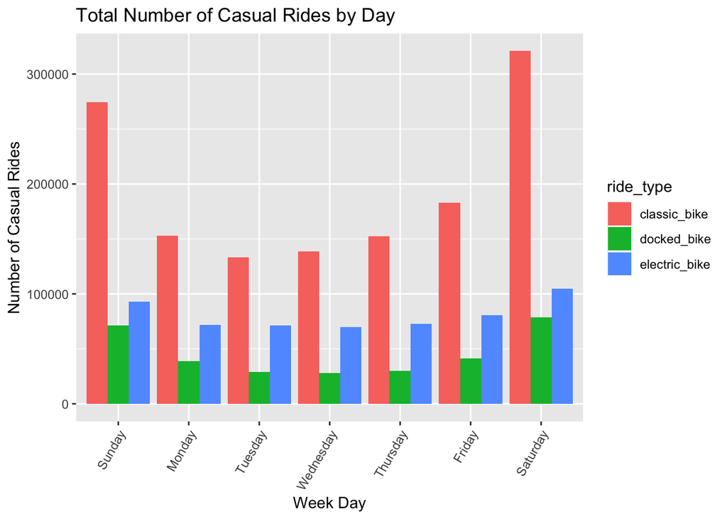

```r
all_trips_casual %>%
  group_by(ride_type, day_of_week) %>%
  summarise(number_of_rides = n(), average_duration = mean(ride_length)) %>%
  arrange(ride_type, day_of_week)%>%
  ggplot(aes(x = day_of_week, y = number_of_rides, fill = ride_type)) +
  geom_col(position = "dodge") + labs(title="Total Number of Casual Rides by Day", x = "Week Day", y = "Number of Casual Rides") + theme(axis.text.x = element_text(angle = 60, hjust = 1))
```

Classic bikes are the favorite for casual riders then electric bikes and lastly docked bikes.

## Analyze casual riders bike type usage by month

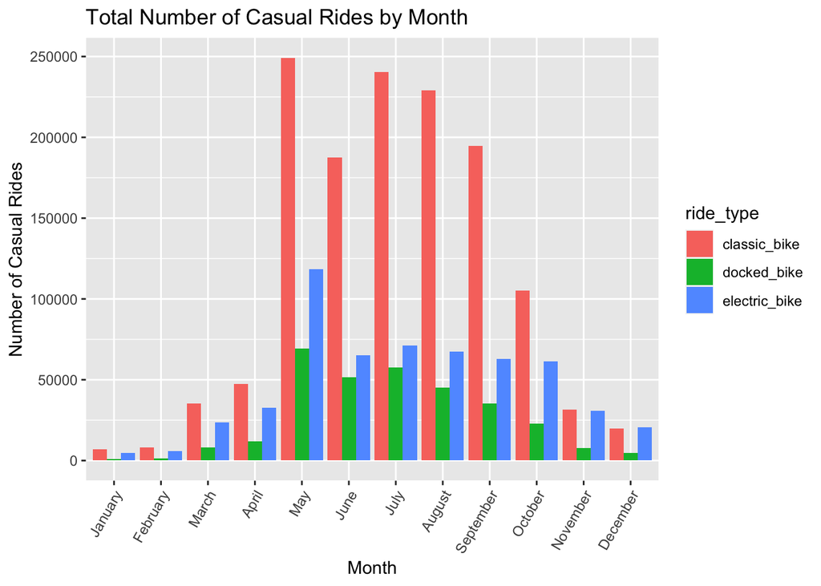

```r
all_trips_casual %>%
  group_by(ride_type, month) %>%
  summarise(number_of_rides = n(), average_duration = mean(ride_length)) %>%
  arrange(ride_type, month) %>%
  ggplot(aes(x = month, y = number_of_rides, fill = ride_type)) +
  geom_col(position = "dodge") + labs(title="Total Number of Casual Rides by Month", x = "Month", y = "Number of Casual Rides") + theme(axis.text.x = element_text(angle = 60, hjust = 1))
```

Not a surprise classic bikes are the most popular bikes used by casual riders during the summer months

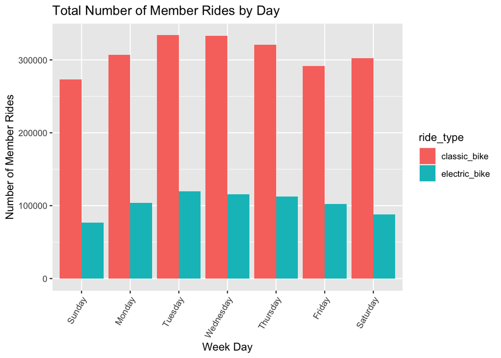

```r
all_trips_member %>%
  group_by(ride_type, day_of_week) %>%
  summarise(number_of_rides = n(), average_duration = mean(ride_length)) %>%
  arrange(ride_type, day_of_week)%>%
  ggplot(aes(x = day_of_week, y = number_of_rides, fill = ride_type)) +
  geom_col(position = "dodge") + labs(title="Total Number of Member Rides by Day", x = "Week Day", y = "Number of Member Rides") + theme(axis.text.x = element_text(angle = 60, hjust = 1))
```

There are no usage for docked bikes for members. The most popular bike used by members is by far the classic bike and it is almost evenly used each day.

## Analyze member riders bike type usage by month

[figure not shown]

```r
## Analyze casual riders bike type usage by month
all_trips_member %>%
  group_by(ride_type, month) %>%
  summarise(number_of_rides = n(), average_duration = mean(ride_length)) %>%
  arrange(ride_type, month) %>%
  ggplot(aes(x = month, y = number_of_rides, fill = ride_type)) +
  geom_col(position = "dodge") + labs(title="Total Number of Member Rides by Month", x = "Month", y = "Number of Casual Rides") + theme(axis.text.x = element_text(angle = 60, hjust = 1))
```

The month of May has the most rides for both ride types.

## What are the most popular routes by casual riders?

## Create new column with route in the casual riders data frame

```r
all_trips_casual <- all_trips_casual %>%
  mutate(route = paste(from_station_name, "To", sep=" "))


all_trips_casual <- all_trips_casual %>%
  mutate(route = paste(route, to_station_name, sep =" "))
```

## Find the most popular route by number of casual rides

```r
popular_ride_route_casual <- all_trips_casual %>%
  group_by(route) %>%
  summarise(number_of_rides  = n(), average_duration_minutes = mean(ride_length)) %>%
  arrange(route, number_of_rides, average_duration_minutes)
```

## New data frame with top ten routes for casual riders

```r
popular_ride_route_casual_top10 <- head(arrange(popular_ride_route_casual, desc(number_of_rides)),10)

head(popular_ride_route_casual_top10, 10)
```

| route | number_of_rides | average_duration_minutes |
| --- | --- | --- |
| Streeter Dr & Grand Ave To Streeter Dr & Grand Ave | 13195 | 47.34500 |
| Michigan Ave & Oak St To Michigan Ave & Oak St | 6241 | 52.43611 |
| Millennium Park To Millennium Park | 6050 | 48.43379 |
| DuSable Lake Shore Dr & Monroe St To DuSable Lake Shore Dr & Monroe St | 4921 | 40.58699 |
| DuSable Lake Shore Dr & Monroe St To Streeter Dr & Grand Ave | 4000 | 29.73190 |
| Streeter Dr & Grand Ave To Millennium Park | 3799 | 35.14942 |
| Millennium Park To Streeter Dr & Grand Ave | 3411 | 51.07872 |
| Montrose Harbor To Montrose Harbor | 3324 | 56.73119 |
| Shedd Aquarium To Streeter Dr & Grand Ave | 3299 | 36.80205 |
| Theater on the Lake To Theater on the Lake | 3296 | 48.91756 |

## What are the most popular routes by member riders?

## Create new column with route in the member riders data frame

```r
all_trips_member <- all_trips_member %>%
  mutate(route = paste(from_station_name, "To", sep=" "))


all_trips_member <- all_trips_member %>%
  mutate(route = paste(route, to_station_name, sep =" "))
```

## Find the most popular route by number of member rides

```r
popular_ride_route_member <- all_trips_member %>%
  group_by(route) %>%
  summarise(number_of_rides  = n(), average_duration_minutes = mean(ride_length)) %>%
  arrange(route, number_of_rides, average_duration_minutes)
```

```r
popular_ride_route_member_top10 <- head(arrange(popular_ride_route_member, desc(number_of_rides)),10)

head(popular_ride_route_member_top10, 10)
```

| route | number_of_rides | average_duration_minutes |
| --- | --- | --- |
| Ellis Ave & 60th St To University Ave & 57th St | 5667 | 5.512315 |
| Ellis Ave & 60th St To Ellis Ave & 55th St | 5539 | 5.787469 |
| University Ave & 57th St To Ellis Ave & 60th St | 5425 | 5.009917 |
| Ellis Ave & 55th St To Ellis Ave & 60th St | 4877 | 5.787919 |
| Calumet Ave & 33rd St To State St & 33rd St | 2440 | 4.082705 |
| State St & 33rd St To Calumet Ave & 33rd St | 2317 | 4.919715 |
| Loomis St & Lexington St To Morgan St & Polk St | 2305 | 5.391414 |
| Morgan St & Polk St To Loomis St & Lexington St | 2129 | 6.093419 |
| Ellis Ave & 60th St To Ellis Ave & 58th St | 1811 | 3.706974 |
| Loomis St & Lexington St To Halsted St & Polk St | 1722 | 7.457288 |

# What does the data say?

The average ride length for a casual rider is approximately 31 minutes and for a member rider, it is about 13 minutes. On average the casual rider is almost riding 2.5 times more minutes than a member rider.

The average ride length for a casual rider is almost consistent throughout the week with an increase during the weekend. The average ride duration for member riders is consistent throughout the week from Monday to Friday at approximately 12 minutes slightly increasing to 14 minutes on Saturday and Sunday.

Even though casual riders ride longer during the weekend they take more weekly trips. Looking at all casual rides, casual rides that occur from Monday to Friday account for approximately 58% of all casual rides. Casual riders enjoy riding during the summer months from June to September as those months account for 58.5% of all casual ride trips. On the other hand, only 44.7% of member total rides occur during the summer months.

Each user type has different top ten routes when cycling. There is not one route that overlaps. The top route for casual riders is Streeter Dr & Grand Ave to Street Dr & Grand Ave. The top route for casual riders is near many attractions such as the Navy Pier, the beach, and the Chicago Children’s Discover museum. Casual riders may be renting these bikes for the day and riding them around nearby attractions and returning them where they originally rented them.

The top route for member riders is Ellis Ave & 60th St To University Ave & 57th St. This route is nearby the University of Chicago, UChicago Law School, and the UChicago Hospital. On average it takes a member 5.5 minutes to complete the route. Members of Cyclistic can be working professionals or students who need a quick ride across campus or their workplace.

# Step 5: Recommendations

The marketing team sould focus on the top 10 routes for casual members during the summer months and have more bikes available in those areas. Also the marketing team can run a promotion that entails casual users to ride two days in a row and get their third day half off.

Members do not use docked bikes, they either choose an electric or classic bike. Docked bikes are also the least used bike for casual riders thus it might be smart to stop the production of docked bikes.

Promote the health benefits of riding a bike as a campaign and track the calories lost while riding as in-app feature. Also include what-if scenarios where one can see how many calories they could burn if they cycle a different route, which will promote riders to try it. In addition, once they burn a certain amount of calories one could get a percentage off a membership.

Overall members and casual riders differ in how long and how often they use the bikes. When one has a membership they can receive a discount for longer rides. In addition Cyclistic can provide a mileage rewards program.